Skip to main content

# Block 5: Complementary Data & Neighbourhood Analysis

Author

Zainab Shahzad

Published

November 22, 2026

```r
library(readr)
library(dplyr)
library(tidyr)
library(ggplot2)
library(lubridate)
library(knitr)

site_static <- read_csv("../data/processed/site_static.csv")
site_daily  <- read_csv("../data/processed/site_daily.csv")
```

## 1. Data & Provenance

Five complementary datasets were downloaded for all five FLUXNET towers (**JP-Yms**, **US-NC2**, **CN-BeO**, **NZ-Lau**, **DE-RuM**), plus **deadtrees.earth** for the European tower (**DE-RuM**; non-European towers are skipped by the dataset).

**Service & download notes:** * **MODIS MOD13Q1:** At the time of analysis (`2026-11-21` to `2026-11-22`), the ORNL DAAC MODIS subsetting REST API (`https://modis.ornl.gov/rst/api/v1/products`) failed the SSL handshake (`SEC_E_UNTRUSTED_ROOT`), so `08_modis_ndvi_evi.R` could not download NDVI/EVI. Missing values are left as `NA` rather than filled manually. * **PlantTraits:** Six non-experimental traits (`SLA`, `leaf_N_mass`, `leaf_N_area`, `stem_density`, `rooting_depth`, `leaf_area`) were downloaded via `05_planttraits.R` on `2026-11-22`. The experimental `plant_height*` map (TRY 3106) was omitted from `05_planttraits.R` after repeated `/vsicurl/` read failures on Zenodo.

| Dataset | Source | Resolution | Period | Accessed | Citation |
| --- | --- | --- | --- | --- | --- |
| **FLUXNET2015 / ICOS** | FLUXNET / ICOS | Point (100 m – 1 km footprint), daily | 2000–2025 (site-dependent) | Block 4 | Pastorello et al. (2020) *Sci. Data* 7, 225 |
| **WorldClim 2.1** | worldclim.org | 5′ (~9 km) | 1970–2000 (climatology) | 2026-11-21 | Fick & Hijmans (2017) *Int. J. Climatol.* 37, 4302–4315 |
| **Dheed** | Zenodo (doi:10.5281/zenodo.14884254) | 0.25° (~28 km), daily | 1950–2023 | 2026-11-21 | Weynants et al. (2025) *ESSD* 17, 6621 |
| **SoilGrids 2.0** | ISRIC (`rest.isric.org`) | 250 m (0–30 cm topsoil) | Static | 2026-11-21 | Poggio et al. (2021) *SOIL* 7, 217–240 |
| **PlantTraits** | `planttraits.earth` / Zenodo (doi:10.5281/zenodo.14646322) | 1 km (community-weighted mean) | Static | 2026-11-22 | Lusk et al. (2026) *Nat. Commun.* 17, 1203 |
| **iNaturalist** | `api.inaturalist.org/v1` | 5 km radius (research-grade) | ~2008–2026 | 2026-11-21 | iNaturalist contributors (2026), accessed 2026-11-21 |
| **deadtrees.earth** | deadtrees.earth | 10 m, yearly (Europe only; DE-RuM) | 2017–2025 | 2026-11-21 | Mosig et al. (2026) *Remote Sens. Environ.* 332, 115027 |
| **MODIS MOD13Q1** | NASA LP DAAC / ORNL DAAC | 250 m (9 × 9 window), 16-day | 2000–today *(unavailable: SSL error)* | 2026-11-22 | Didan (2021) doi:10.5067/MODIS/MOD13Q1.061 |

## 2. Site Portrait (`site_static`)

```r
site_static |>
  select(
    `Site ID` = site_id,
    `IGBP` = igbp,
    `Country` = country,
    `First Year` = first_year,
    `Last Year` = last_year,
    `BIO1 (°C)` = BIO1,
    `BIO4 (°C)` = BIO4,
    `BIO12 (mm)` = BIO12,
    `BIO15 (%)` = BIO15,
    `Clay (%)` = soil0_30_clay,
    `Sand (%)` = soil0_30_sand,
    `SOC (g kg⁻¹)` = soil0_30_soc,
    `pH (H2O)` = soil0_30_phh2o,
    `BD (kg dm⁻³)` = soil0_30_bdod,
    `N (g kg⁻¹)` = soil0_30_nitrogen,
    `CEC (cmol(c) kg⁻¹)` = soil0_30_cec,
    `SLA (m² kg⁻¹)` = SLA,
    `Leaf N mass (mg g⁻¹)` = leaf_N_mass,
    `Leaf N area (g m⁻²)` = leaf_N_area,
    `Stem density (g cm⁻³)` = stem_density,
    `Rooting depth (m)` = rooting_depth,
    `Leaf area (mm²)` = leaf_area,
    `iNat Obs (n)` = n_obs,
    `iNat Species (n)` = n_species,
    `Plant Species (n)` = n_plant_species
  ) |>
  kable(digits = 2, caption = "Static environmental portrait of the five assigned FLUXNET towers.")
```

Static environmental portrait of the five assigned FLUXNET towers.

| Site ID | IGBP | Country | First Year | Last Year | BIO1 (°C) | BIO4 (°C) | BIO12 (mm) | BIO15 (%) | Clay (%) | Sand (%) | SOC (g kg⁻¹) | pH (H2O) | BD (kg dm⁻³) | N (g kg⁻¹) | CEC (cmol(c) kg⁻¹) | SLA (m² kg⁻¹) | Leaf N mass (mg g⁻¹) | Leaf N area (g m⁻²) | Stem density (g cm⁻³) | Rooting depth (m) | Leaf area (mm²) | iNat Obs (n) | iNat Species (n) | Plant Species (n) |
| --- | --- | --- | --- | --- | --- | --- | --- | --- | --- | --- | --- | --- | --- | --- | --- | --- | --- | --- | --- | --- | --- | --- | --- | --- |
| JP-Yms | DBF | JP | 2000 | 2023 | 13.94 | 830.44 | 1551 | 48.69 | 27.38 | 34.98 | 30.10 | 5.40 | 1.13 | 2.15 | 18.50 | 15.31 | 18.28 | 1.27 | 0.52 | 0.66 | 1334.41 | 146 | 107 | 21 |
| US-NC2 | ENF | US | 2005 | 2025 | 15.97 | 755.20 | 1252 | 22.20 | 21.97 | 41.52 | 51.22 | 4.65 | 1.52 | 3.20 | 18.52 | 16.98 | 18.91 | 1.19 | 0.51 | 0.58 | 1504.96 | 38 | 33 | 7 |
| CN-BeO | MF | CN | 2012 | 2020 | 12.15 | 1118.11 | 546 | 134.42 | NA | NA | NA | NA | NA | NA | NA | NA | NA | NA | NA | NA | NA | 3000 | 591 | 199 |
| NZ-Lau | GRA | NZ | 2019 | 2025 | 9.45 | 493.44 | 603 | 21.05 | 22.37 | 56.32 | 40.60 | 6.53 | 1.07 | 2.17 | 30.25 | 18.00 | 22.06 | 1.41 | 0.40 | 0.44 | 546.24 | 60 | 45 | 30 |
| DE-RuM | CRO | DE | 2011 | 2019 | 10.03 | 572.88 | 724 | 12.19 | 23.00 | 14.17 | 15.72 | 6.62 | 1.33 | 1.79 | 16.62 | 20.72 | 25.27 | 1.22 | 0.33 | 0.47 | 1185.55 | 513 | 285 | 93 |

## 3. Time Series: GPP and Satellite Greenness

```
**Note:** MODIS MOD13Q1 columns (`ndvi`, `evi`) are absent because `modis.ornl.gov` returned an SSL certificate error during data collection. Daily GPP is shown below without satellite greenness.
```

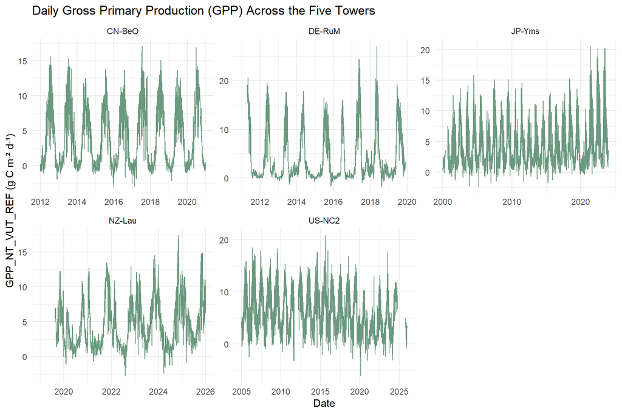

```r
has_modis <- all(c("ndvi", "evi") %in% names(site_daily))

if (has_modis) {
  site_daily |>
    mutate(date = as.Date(date)) |>
    ggplot(aes(x = date)) +
    geom_line(aes(y = GPP_NT_VUT_REF, colour = "GPP (g C m⁻² d⁻¹)"), alpha = 0.7) +
    geom_line(aes(y = evi * 15, colour = "EVI (×15)"), alpha = 0.8) +
    geom_line(aes(y = ndvi * 15, colour = "NDVI (×15)"), linetype = "dashed", alpha = 0.8) +
    facet_wrap(~ site_id, scales = "free") +
    labs(
      title = "Daily GPP and MODIS Vegetation Indices",
      x = "Date", y = "GPP (g C m⁻² d⁻¹) / Scaled Index", colour = NULL
    ) +
    theme_minimal()
} else {
  cat("**Note:** MODIS MOD13Q1 columns (`ndvi`, `evi`) are absent because `modis.ornl.gov` returned an SSL certificate error during data collection. Daily GPP is shown below without satellite greenness.\n")
  site_daily |>
    mutate(date = as.Date(date)) |>
    ggplot(aes(x = date, y = GPP_NT_VUT_REF)) +
    geom_line(colour = "#2c6e49", alpha = 0.7) +
    facet_wrap(~ site_id, scales = "free") +
    labs(
      title = "Daily Gross Primary Production (GPP) Across the Five Towers",
      x = "Date",
      y = "GPP_NT_VUT_REF (g C m⁻² d⁻¹)"
    ) +
    theme_minimal()
}
```

## 4. Research Question: Were the Tower Years Normal? (Question 4)

We compare each complete tower-year’s mean air temperature (`TA_F`) and total precipitation (`P_F`) against the 1970–2000 WorldClim 2.1 climate normal (`BIO1` and `BIO12`).

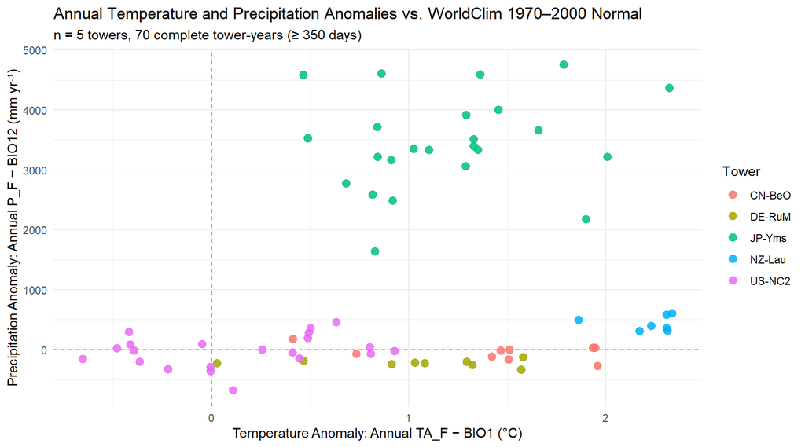

```r
annual_climate <- site_daily |>
  mutate(date = as.Date(date), year = year(date)) |>
  group_by(site_id, year) |>
  summarise(
    n_days = n(),
    ta_mean = mean(TA_F, na.rm = TRUE),
    p_sum   = sum(P_F, na.rm = TRUE),
    .groups = "drop"
  ) |>
  filter(n_days >= 350) |>
  left_join(site_static |> select(site_id, BIO1, BIO12), by = "site_id") |>
  mutate(
    ta_anom = ta_mean - BIO1,
    p_anom  = p_sum - BIO12
  )

n_towers <- n_distinct(annual_climate$site_id)
n_years  <- nrow(annual_climate)

ggplot(annual_climate, aes(x = ta_anom, y = p_anom, colour = site_id)) +
  geom_hline(yintercept = 0, linetype = "dashed", colour = "grey50") +
  geom_vline(xintercept = 0, linetype = "dashed", colour = "grey50") +
  geom_point(size = 2.8, alpha = 0.85) +
  labs(
    title = "Annual Temperature and Precipitation Anomalies vs. WorldClim 1970–2000 Normal",
    subtitle = paste0("n = ", n_towers, " towers, ", n_years, " complete tower-years (≥ 350 days)"),
    x = "Temperature Anomaly: Annual TA_F − BIO1 (°C)",
    y = "Precipitation Anomaly: Annual P_F − BIO12 (mm yr⁻¹)",
    colour = "Tower"
  ) +
  theme_minimal()
```

Across n = 5 towers and 70 complete tower-years (>= 350 days), most observed years were warmer than the 1970–2000 WorldClim 2.1 baseline (BIO1), with only US-NC2 recording several cooler-than-normal years (down to roughly -0.6 °C). In contrast, CN-BeO, DE-RuM, JP-Yms, and NZ-Lau were warmer than BIO1 in every complete year, with NZ-Lau showing the largest positive temperature anomalies (around +1.8 to +2.3 °C). Precipitation anomalies (P_F - BIO12) were relatively modest at DE-RuM (consistently slightly drier than normal) and CN-BeO (near or slightly below normal), while US-NC2 spanned both wetter and drier years. NZ-Lau was consistently wetter than BIO12 by roughly 300 to 600 mm/yr. Most strikingly, JP-Yms shows positive precipitation anomalies of roughly +1,600 to +4,800 mm/yr across all years, which likely reflects a scale mismatch between the 9 km WorldClim grid cell and local topography or microclimate rather than a purely climatic shift. Overall, these results show recent warming relative to 1970–2000 across the sites, while highlighting that subtracting a coarse 9 km climatology from point tower measurements can introduce systematic site-level offsets.

## 5. Scale Discussion

- **FLUXNET tower footprint (~100 m – 1 km):** The eddy-covariance tower measures net fluxes over the upwind vegetation canopy at a local scale of roughly 100 m to 1 km.
- **deadtrees.earth (10 m, 2 × 2 km window):** Finer than the tower footprint, resolving individual canopy gaps and standing deadwood within a 2 × 2 km box around **DE-RuM**.
- **SoilGrids 2.0 (250 m) & MODIS MOD13Q1 (250 m, 9 × 9 window):** SoilGrids is comparable to the core tower footprint, whereas a 9 × 9 MODIS window (~2 × 2 km) averages across a slightly broader landscape.
- **PlantTraits (1 km):** Matches the upper end of a typical flux tower footprint, though modelled community-weighted means can extrapolate poorly in croplands (such as **DE-RuM**) or heterogeneous landscapes.
- **WorldClim 2.1 (5′ ≈ 9 km):** Much coarser than the tower footprint; a 9 km cell can smooth over local topography, elevation gradients, or microclimates, which can introduce systematic offsets when subtracting `BIO1` or `BIO12` from tower `TA_F` and `P_F`.
- **Dheed (0.25° ≈ 28 km):** Far coarser than the tower footprint; useful for identifying regional compound hot-dry events, though local tower conditions (`TA_F`, `VPD_F`) must still be checked to confirm whether the tower itself experienced stress.
- **iNaturalist (5 km radius):** Reflects citizen-science observations within 5 km, which are biased toward roads, trails, and accessible areas rather than systematic ecological plots inside the flux footprint.